# Activity 11 - Practicing with Intervals for Differences

STS 2300 - Solutions

Updated: 2025-11-09

Below are the packages you will need for this activity. If you use other packages, you can add them here.

```r
library(ggplot2)
library(infer)
library(dplyr)
```

**To have this activity marked as “Complete”**: You need to complete **either** Part 1 (interval for differences in means) or Part 2 (interval for differences in proportions). I encourage you to attempt both, but only one is required for this activity. If you only choose one, focus on the interval (means or proportions) that you did not do in Activity 10, or the one you feel like you need most practice with.

# Part 1 - Fidget spinners and attention

A study looked at the effect that fidget spinners have on attention and memory. You can read an article about it [here](https://www.psypost.org/2019/11/study-finds-using-a-fidget-spinner-can-impair-memory-and-attention-54904) or look at the research paper [here](https://onlinelibrary.wiley.com/doi/full/10.1002/acp.3610) if you’re interested.

The researchers wanted to know how attention might differ between people using and not using a fidget spinner. The code below will read data from the study directly into R and subset the data to remove a control group where no fidget spinner was used. This leaves us with two groups in the `Condition` variable: “Spinner” (actively using a fidget spinner) and “Spinner Present” (near someone who was using a fidget spinner).

```r
fidget <- read.csv("https://raw.githubusercontent.com/nbussberg/STS2300-Fall2025/refs/heads/main/Data/fidget_spinners.csv") |>
  filter(Condition != "No Spinner")
```

1. Create a graph that can be used to explore how `AttentionScore` differs between people using a fidget spinner and people near someone using a fidget spinner. Describe what the graph shows about the distribution of `AttentionScore` between these two groups.

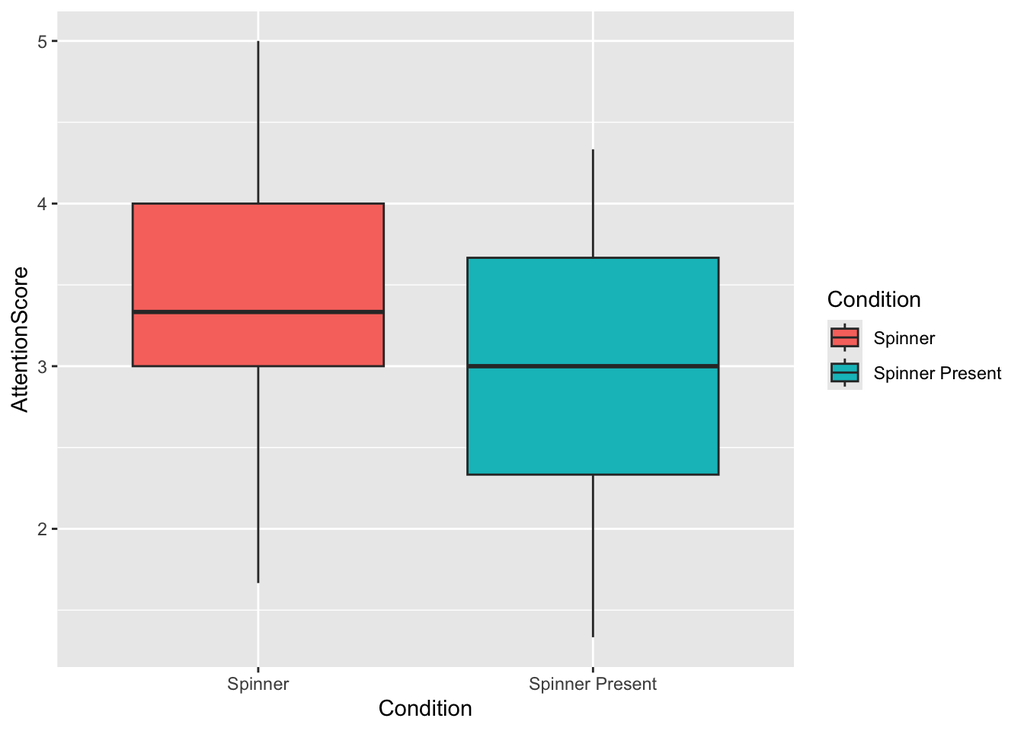

```r
fidget_graph <- ggplot(data = fidget) +
  geom_boxplot(aes(x = Condition, y = AttentionScore, fill = Condition))

fidget_graph
```

**Graph description:** Those with the Spinner seem to have a slightly higher attetion score overall.

2. Calculate a difference in sample mean attention scores between the two groups. Use “Spinner” - “Spinner Present” as the order of subtraction. Write a sentence about what the value you get means in context of this example. Additionally, write out a sentence describing the corresponding paramater of interest.

```r
fidget_diff_samp_means <- fidget |>
  specify(formula = AttentionScore ~ Condition) |>
  calculate(stat = "diff in means", order = c("Spinner", "Spinner Present"))

fidget_diff_samp_means$stat
```

```
## [1] 0.4040404
```

**Sentence about difference in sample means:** The difference in sample mean attention scores of students using fidget toys and those who don’t use fidget toys/toys are still present is 0.4. This implies that the Spinner group may have a higher attention score (on average) than the Spinner Present group.

**Parameter of interest:** The difference in population mean attention scores between groups where a spinner is actively being played with and when the toy is only present (i.e., not being played with).

3. Generate a bootstrap distribution to better understand sampling variability in your estimate. Make a histogram of this distribution and comment on what you see. (Note: The `set.seed()` line will ensure we get the same result each time we knit our document. You should replace the number with a number of your choosing.)

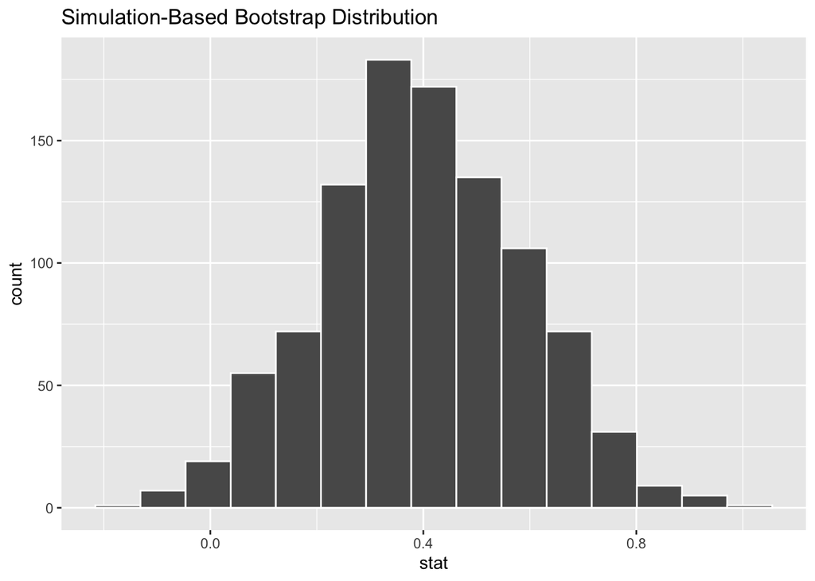

```r
set.seed(92520)

fidget_boot <- fidget |>
  specify(formula = AttentionScore ~ Condition) |>
  generate(reps = 1000, type = "bootstrap") |>
  calculate(stat = "diff in means", order = c("Spinner", "Spinner Present"))
visualize(fidget_boot)
```

**Description of bootstrap:** The shape of the graph is roughly bell-shaped. The center is around 0.4 (the difference in sample means), and the spread is generally between 0 and 0.8.

4. Calculate a confidence interval for the difference in population means that uses your bootstrap distribution. Write your interval below. (Note: I didn’t specify a confidence level, so you can choose one)

```r
fidget_boot |>
  get_ci(level = 0.95, type = "se", point_estimate = fidget_diff_samp_means)
```

```
## # A tibble: 1 × 2
##   lower_ci upper_ci
##      <dbl>    <dbl>
## 1   0.0328    0.775
```

**CI:** (0.033, 0.775)

5. Provide an interpretation of your confidence interval in context of this example. Additionally, consider whether it seem like fidget spinners help (or hurt) memory on average.

**Interpretation:** We are 95% confident that the population mean attention score is between 0.033 and 0.775 greater for those using a fidget spinner compared to those who have one present.

6. Based on your results, what takeaways can we make (or not make) about the impact of fidget spinners on attention?

**Answer:** We can make the argument that those using fidget spinners are more likely to have a higher attention score.

7. For practice, make a theory-based confidence interval for this example as well.

```r
t.test(AttentionScore ~ Condition, data = fidget,
       conf.level = 0.95)
```

```
##
##  Welch Two Sample t-test
##
## data:  AttentionScore by Condition
## t = 2.0821, df = 63.609, p-value = 0.04136
## alternative hypothesis: true difference in means between group Spinner and group Spinner Present is not equal to 0
## 95 percent confidence interval:
##  0.01633406 0.79174675
## sample estimates:
##         mean in group Spinner mean in group Spinner Present
##                      3.393939                      2.989899
```

**CI:** (0.016, 0.792)

8. How broadly do you think these conclusions (from your CI) might apply? Consider who makes up the sample and whether you think it’s likely this was a random sample.

**Answer:** This is unlikely to be a true random sample, because this is an experiment. Likely, kids were recruited for the study, from the local area where the experiment took place. We hope that the findings generalize to all kids in a similar age range, but kids in other cities (or countries) may show different results.

# Part 2 - Airbnb Discrimination

The code below will read a data frame into R from a study on potential discrimination by Airbnb hosts. In the experiment, researchers sent requests to Airbnb hosts asking to stay at their properties. The only difference on each request was the name that was used. Researchers chose names that were predominantly associated with certain genders and races (determined in a separate study) and randomly assigned a name to each request. They then recorded whether or not the host gave a positive response indicating the person could stay there.

Our goal will be to determine the difference in proportion of positive responses given by hosts who received a request from a predominantly Black name versus a predominantly white name.

```r
airbnb <- read.csv("https://raw.githubusercontent.com/nbussberg/STS2300-Fall2025/refs/heads/main/Data/airbnb.csv")
```

9. Make a bar graph (using `geom_bar()`) to compare the proportion of positive responses between the two races used in this study. Briefly describe what the graph shows about our sample. (Note: You want your variable that creates groups (`Race`) to go on the x-axis and your variable of interest (`Response`) to map to fill. Use the `position = "fill"` argument inside `geom_bar()` to get a graph comparing proportions.)

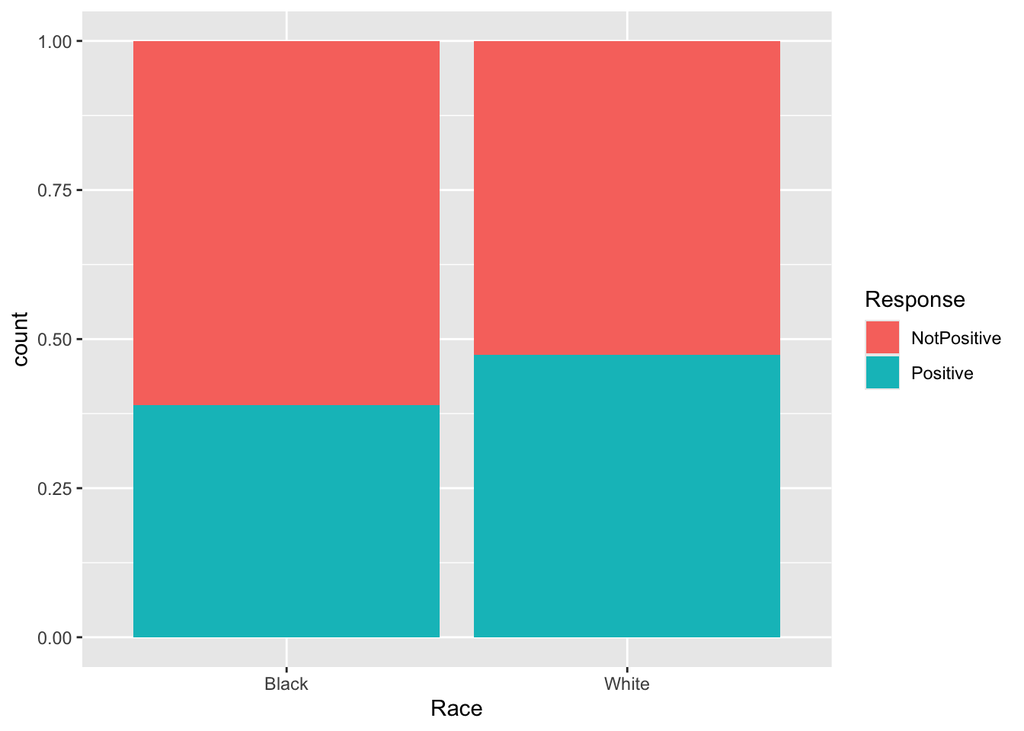

```r
air_graph <- ggplot(airbnb, aes(x = Race, fill = Response)) +
  geom_bar(position = "fill")

air_graph
```

**Description of graph:** We can see there is a greater amount of positive responses to white guests than black guests with the bar graph.

10. What is the parameter of interest for this example? Write it out in words below.

**Parameter of interest:** The differences in population proportions of positive responses received by white guests and black guests.

11. We can calculate point estimates by writing code for a bootstrap distribution but leaving out the `generate()` argument (i.e., only using `specify()` and `calculate()`). Calculate a difference in sample proportions in this way and explain what the value you get means in this context.

```r
air_pointest <- airbnb |>
  specify(Response ~ Race, success = "Positive") |>
  calculate(stat = "diff in props", order = c("White", "Black"))
air_pointest$stat
```

```
## [1] 0.08513317
```

**Answer:** We get a value of 0.0851. This estimate is from taking the sample proportion of positive responses to white guests and subtracting the proportion of positive responses to black guests. This implies that white guests received 8.51 percentage points more positive responses than black guests.

12. Write code to generate a bootstrap distribution. You can reuse your code from the previous question and add in a `generate()` line between `specify()` and `calculate()`. Describe what your bootstrap distribution shows. (Note: remember to set a seed)

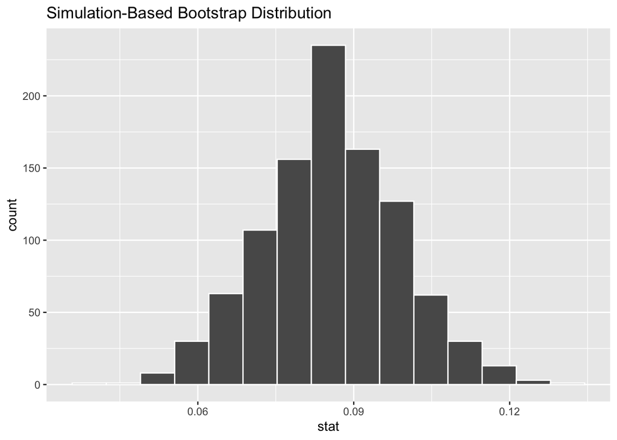

```r
set.seed(64)
air_boot <- airbnb |>
  specify(formula = Response ~ Race, success = "Positive") |>
  generate(reps = 1000, type = "bootstrap") |>
  calculate(stat = "diff in props", order = c("White", "Black"))

visualize(air_boot)
```

**Description:** Roughly bell-shaped, normal curve. More or less spread from 0.06 to 0.11. Centered around 0.085 (the difference in sample proportions).

13. Generate a 95% confidence interval using your bootstrap distribution.

```r
air_boot |>
  get_ci(level = 0.95, type = "se", point_estimate = air_pointest)
```

```
## # A tibble: 1 × 2
##   lower_ci upper_ci
##      <dbl>    <dbl>
## 1   0.0594    0.111
```

**95% CI:** (0.059, 0.111)

14. Interpret your interval in context of this example. Your sentence should be understandable by someone reading a news story about this experiment. (Note: When talking about a difference in percentages, you will use the phrase “percentage points”)

**Interpretation:** We are 95% confident that the population proportion of positive responses is between 0.06 and 0.1 greater for white guests than black guests asking about Airbnbs.

15. As practice, calculate a 95% theory-based interval based on this data.

```r
prop.test(x = c(1498, 1210),
          n = c(3159, 3110),
          conf.level = 0.95)
```

```
##
##  2-sample test for equality of proportions with continuity correction
##
## data:  c(1498, 1210) out of c(3159, 3110)
## X-squared = 45.943, df = 1, p-value = 1.217e-11
## alternative hypothesis: two.sided
## 95 percent confidence interval:
##  0.06038467 0.10988168
## sample estimates:
##    prop 1    prop 2
## 0.4742007 0.3890675
```

**95% CI:** (0.060, 0.110)